# Non-Metallic Mineral Products Research Project

March 9, 2016

## 1. Introduction

In this project, we focus on finding a good model fitting for Non-Metallic Mineral Products data from U.S. Census website. We expect this time series with highly singnificant seasonality; therefore, trying to fit SARIMA model, Linear regression with SARIMA error model, and Model with a band pass filter will be some reasonable methods. we will also analyze the sptrum density of those time series to further understand the frequencies of seasonalities. The data we use for linear regression is Total Manufacturing Products data which is a general market situation of the Non-Metallic Mineral Products data.

## 2. Reading in the data

This historical data we are using in this report here is downloaded from U.S. census Bureau Website, which is about the value of U.S. Total Manufacturers’ Shipments, Inventories, and Orders (Definitions are here: http://www.census.gov/manufacturing/m3/definitions/index.html). This data we use contains two time series, one is Not Seasonally Adjusted Value of Shipments of Nonmetallic Mineral Products, the other is Not Seasonally Adjusted Value of Shipments of Total Manufacturing products. Both of values for two time series are recorded in Millions of Dollars. The time interval of this data is 1992 to 2016 monthly data.

```r
Mine_data <- read.csv("Project_data.csv")
head(Mine_data,5)
```

```
##   Period NMUnAdj TotalMUnAdj
## 1 Jan-92    4077      209438
## 2 Feb-92    4477      232679
## 3 Mar-92    5001      249673
## 4 Apr-92    5144      239666
## 5 May-92    5203      243231
```

```r
Mine_data <- na.omit(Mine_data)
Mine_data$Period <- seq(from = 1992, length = length(Mine_data$Period), by = 1/12)
```

The variable NMUnAdj is Not Seasonally Adjusted Value of Shipments of Nonmetallic Mineral Products, and TotalMUnAdj is Not Seasonally Adjusted Value of Shipments of Total Manufacturing products. There are also many other categories in U.S. Total Manufacturers’ Shipments, Inventories, and Orders. Nonmetallic Mineral Products is just one of them, and the sum of values of those categories will become the total value we used here.

For notation convenience, we set the Nonmetallic Mineral data as ${u_n^*}$ and the Total Manufacturing data as ${v_n^*}$ which both time series in month ${t_n} = 1992 + n/12$

## 3. Fitting Models

Here we only take data from Jan-2005 to Jan-2016 to fit the model.

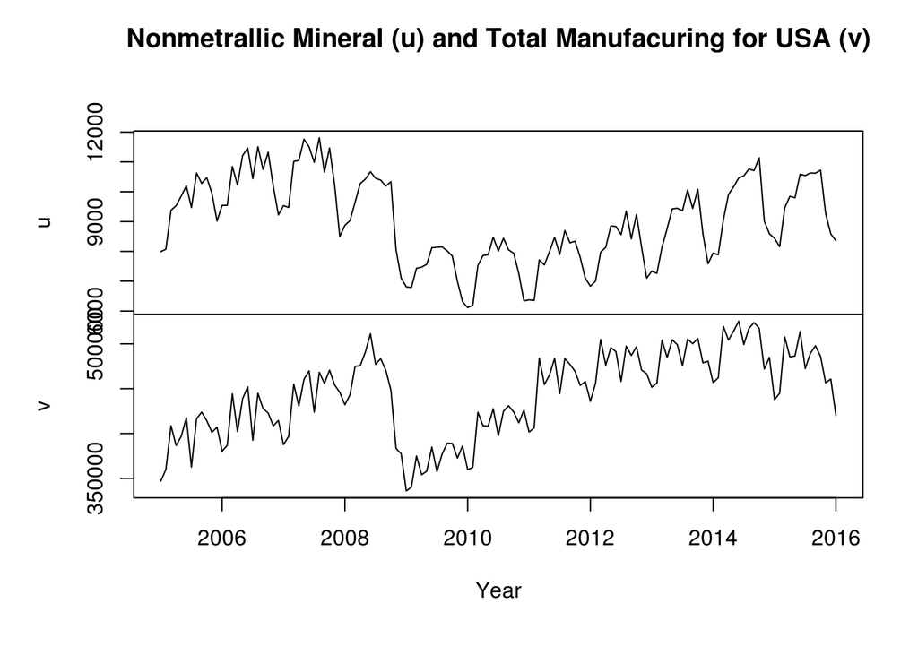

```r
t <- intersect(Mine_data$Period, Mine_data$Period)
t <- t[which(t >= 2005)]
u <- Mine_data$NMUnAdj[Mine_data$Period %in% t]
v <- Mine_data$TotalMUnAdj[Mine_data$Period %in% t]
plot(ts(cbind(u,v),start=2005, frequency = 12), main="Nonmetrallic Mineral (u) and Total Manufacuring for USA (v)",xlab="Year")
```

We first can get some feeling about the data we fit. The plot above shows that two time series have a similar trend shape. It is reasonable, because the total manufacturing represents the overall changing in this field. As a part of the field, Nonmetallic Mineral data is affected by the total data. And it is one of the reason that we are going to use the Total manufacturing data in linear regression to fit the Nonmetallic Mineral data.

### 3.1 Model by Hodrick-Prescott (HP) filter

#### 3.1.1 Filtering by Hodrick-Prescott (HP) filter

We are interested in business cycles after we remove the trend inside this time series. Thus we can use HP-filter to extract cycles from data. HP-filter is a smoothing method has a particular smoothing parameter picked manually. As the class notes indicates, a time series ${y_{1:N}^*}$, the HP filter is the time series ${s_{1:N}^*}$ constructed as ${s_{1:N}^*} = \arg\min_{s_{1:N}} \left\{ \sum^{N}_{n=1}\big({y_n^*}-s_{n}\big)^2 + \lambda\sum^{N-1}_{n=2}\big(s_{n+1}-2s_{n}+s_{n-1}\big)^2 \right\}.$ Because Appropriate values of the smoothing parameter depend upon the periodicity of the data, and this typically choice of $\lambda$ for monthly data is 14400. We call detrended Nonmetallic Mineral $u^{HP*}_{1:N}$ and detrended Total Manufacturing $v^{HP*}_{1:N}$.

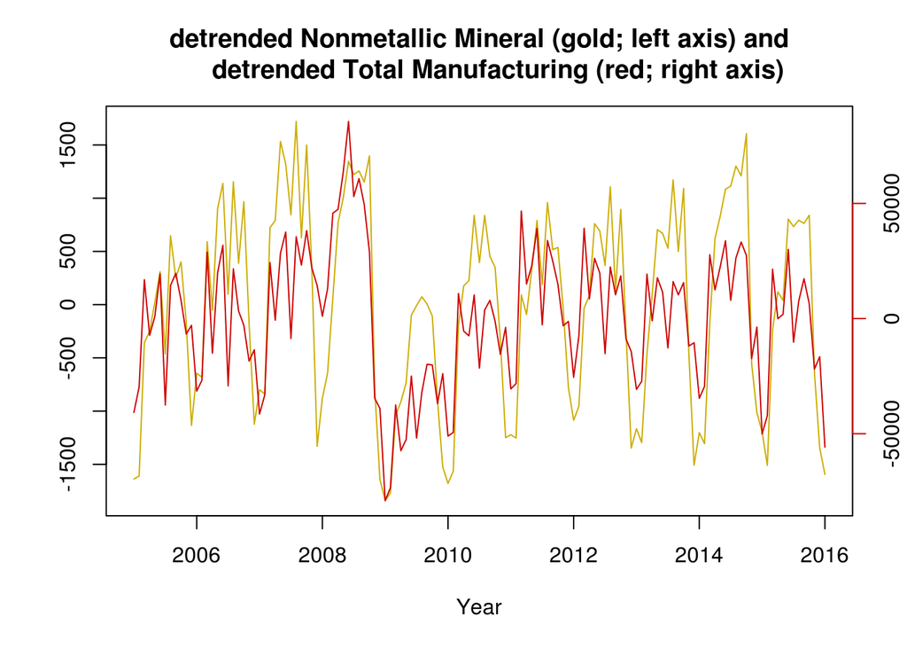

```r
require(mFilter)
u_hp <- hpfilter(u, freq=14400,type="lambda",drift=F)$cycle
v_hp <- hpfilter(v, freq=14400,type="lambda",drift=F)$cycle
plot(t,u_hp,type="l",xlab="Year",ylab="", col="gold3",
     main = "detrended Nonmetallic Mineral (gold; left axis) and
     detrended Total Manufacturing (red; right axis)")
par(new=TRUE)
plot(t,v_hp,col="red3",type="l",axes=FALSE,xlab="",ylab="")
axis(side=4, col="red3")
```

It is kind of obvious that detrended Nonmetallic Mineral product and Total Manufacturing product are cycle together. We also can discover that from the undetrend plot previously, but this is clearer after we detrend two time series.

we want to make a simple test to check that. As class note suggests, one possible way to do this is analyzing $u^{HP*}_{1:N}$ by a regression with ARMA errors model. That means we want to fit: $u^{HP}_n = \alpha + \beta v^{HP*}_n + \epsilon_n,$ where $\epsilon_n$ is a Gaussian ARMA process.

#### 3.1.2 Model Selection by AIC

We want to fit a SARIMA$(p,d,q)\times(P,D,Q)_{12}$ model because we see data has periods and a trend. Because of using Regression with ARMA errors model, it is fine if we are setting $d=0$ and $D=0$. First, we fit a ARIMA model for $p$ and $q$ decide by AIC table, then we fit a SARIMA model by using the $q$ and $p$ from ARIMA to find the $P$ and $Q$ for SARIMA model.

Here is the AIC table for ARIMA(p,q) showing below:

```r
aic_table <- function(data,P,Q,xreg=NULL){
  table <- matrix(NA,(P+1),(Q+1))
  for(p in 0:P) {
    for(q in 0:Q) {
      table[p+1,q+1] <- arima(data,order=c(p,0,q),xreg=xreg, method = "ML")$aic
    }
  }
  dimnames(table) <- list(paste("<b> AR",0:P, "</b>", sep=""),paste("MA",0:Q,sep=""))
  table
}
u_aic_table <- aic_table(u_hp,5,4,xreg=v_hp)
require(knitr)
kable(u_aic_table,digits=2)
```

|  | MA0 | MA1 | MA2 | MA3 | MA4 |
| --- | --- | --- | --- | --- | --- |
| **AR0** | 2081.80 | 2014.05 | 2015.59 | 1982.19 | 1969.11 |
| **AR1** | 2025.56 | 2015.38 | 2015.40 | 1978.30 | 1959.59 |
| **AR2** | 2026.27 | 2011.80 | 2012.69 | 1975.07 | 1961.30 |
| **AR3** | 2027.93 | 2000.12 | 1940.05 | 1973.64 | 1914.41 |
| **AR4** | 1927.68 | 1929.66 | 1928.76 | 1900.13 | 1898.23 |
| **AR5** | 1929.66 | 1925.28 | 1902.99 | 1900.49 | 1872.26 |

There is no clearly a pair of small $p$ and $q$ with relatively low AIC value. Therefore, we choice $p=4$ and $q=0$ suggested by this Table.  
Then we use this pair of $p$ and $q$ for fitting SARIMA model.

```r
aic_table_2 <- function(data,P,Q,xreg=NULL){
  table <- matrix(NA,(P+1),(Q+1))
  for(p in 0:P) {
    for(q in 0:Q) {
      table[p+1,q+1] <- arima(data,order=c(4,0,0),xreg=xreg, seasonal = list(order = c(p,0,q), Period = 12), method = "ML")$aic
    }
  }
  dimnames(table) <- list(paste("<b> SAR",0:P, "</b>", sep=""),paste("SMA",0:Q,sep=""))
  table
}
u_aic_table_2 <- aic_table_2(u_hp,5,4,xreg=v_hp)
require(knitr)
kable(u_aic_table_2,digits=2)
```

|  | SMA0 | SMA1 | SMA2 | SMA3 | SMA4 |
| --- | --- | --- | --- | --- | --- |
| **SAR0** | 1927.68 | 1929.66 | 1928.76 | 1900.13 | 1898.23 |
| **SAR1** | 1929.66 | 1929.65 | 1902.99 | 1900.49 | 1872.11 |
| **SAR2** | 1927.59 | 1927.12 | 1899.96 | 1901.56 | 1873.52 |
| **SAR3** | 1928.05 | 1928.66 | 1897.64 | 1898.47 | 1874.07 |
| **SAR4** | 1958.07 | 1953.83 | 1955.24 | 1931.48 | 1918.82 |
| **SAR5** | 1917.92 | 1919.61 | 1893.03 | 1893.76 | 1896.84 |

This table suggest that $P=1$ and $Q=4$ is the best small model.

There are some large model with lower AIC values. However, those model may not really stable. We may find a similar model for a similar data. In addition, some of those coefficients are really close to 1. Also AIC table has some inconsistencies.

For example: SARIMA$(3,0,2)\times(4,0,4)_{12}$

```r
arima(u_hp,xreg=v_hp,order=c(3,0,2),seasonal = list(order = c(4,0,4), Period = 12), method = "ML")
```

```
##
## Call:
## arima(x = u_hp, order = c(3, 0, 2), seasonal = list(order = c(4, 0, 4), Period = 12),
##     xreg = v_hp, method = "ML")
##
## Coefficients:
##          ar1      ar2     ar3      ma1     ma2    sar1     sar2    sar3
##       0.8352  -0.9941  0.7583  -0.1598  0.9999  0.7313  -0.2593  0.7315
## s.e.  0.0627   0.0338  0.0643   0.0240  0.0545  0.0037   0.0051  0.0038
##          sar4     sma1    sma2     sma3    sma4  intercept    v_hp
##       -0.9996  -0.7277  0.2964  -0.7453  0.9812   -13.8440  0.0258
## s.e.   0.0004   0.0324  0.0375   0.0997  0.0851    85.6465  0.0011
##
## sigma^2 estimated as 47646:  log likelihood = -916.52,  aic = 1865.03
```

This model does have the problems we just talked about, for example $MA_{2}=1$ is not so good.

Generally speaking, we can conclude that SARIMA$(4,0,0)\times(1,0,4)_{12}$ is a relatively good model we can fit.

#### 3.1.3 Supplementary analysis of SARIMA$(4,0,0)\times(1,0,4)_{12}$

```r
arima(u_hp,xreg=v_hp,order=c(4,0,0),seasonal = list(order = c(1,0,4), Period = 12), method = "ML")
```

```
##
## Call:
## arima(x = u_hp, order = c(4, 0, 0), seasonal = list(order = c(1, 0, 4), Period = 12),
##     xreg = v_hp, method = "ML")
##
## Coefficients:
##          ar1      ar2     ar3      ar4    sar1     sma1    sma2     sma3
##       0.7222  -0.2607  0.7285  -0.9930  0.6554  -0.7069  0.3453  -0.6541
## s.e.  0.0106   0.0081  0.0062   0.0093  0.0880   0.1056  0.0445   0.1641
##         sma4  intercept    v_hp
##       0.9684    -8.7430  0.0251
## s.e.  0.1603    69.8988  0.0013
##
## sigma^2 estimated as 56057:  log likelihood = -924.06,  aic = 1872.11
```

Furthermore, we could also compute the p-value of likelihood ratio test.

```r
log_lik_ratio <- as.numeric(
  logLik(arima(u_hp,xreg=v_hp,order=c(4,0,0),seasonal = list(order = c(1,0,4), Period = 12), method = "ML")) -
    logLik(arima(u_hp,order=c(4,0,0),seasonal = list(order = c(1,0,4), Period = 12), method = "ML")))
LRT_pval <- 1-pchisq(2*log_lik_ratio,df=1)
```

We observe that the p-value is a really small number near 0, this will conclude the same result above.

Then we could do Residual Analysis to this model.

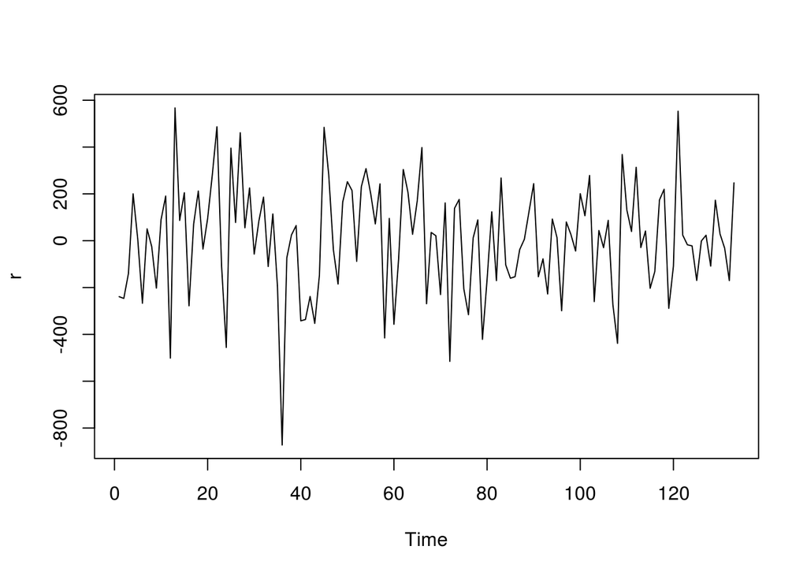

```r
r <- resid(arima(u_hp,xreg=v_hp,order=c(4,0,0),seasonal = list(order = c(1,0,4), Period = 12), method = "ML"))
plot(r)
```

We observe that the amplitude residual is kind of decreasing over time. AS the class notes suggest, it is heteroskedasticity.

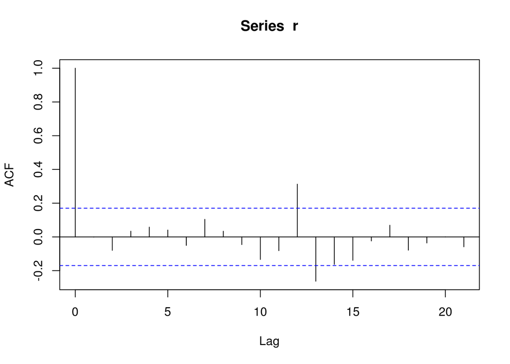

```r
acf(r)
```

It is showing a not very bad results on Acf plot. There are some significant correlations on lag 12, 13 which are all out of the dashed lines showing we cannot accept that our null hypothesis that residual is compeletely a Gaussian white noise. The reason this happen probably will be the lack of fitting seasonal data. Because the observation is recorded monthly, lag 12, 13 are represented around yearly correlations, which means we left some seasonal information in the residuals.

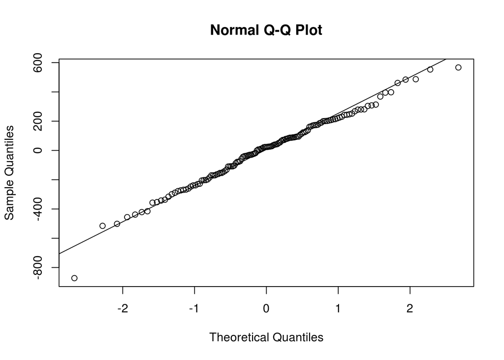

```r
qqnorm(r)
qqline(r)
```

The Normal Q-Q plot indicates that the residuals have mild skewed to the left compared with theoretical quantiles. This shows that the residuals are generally normally distributed.

#### 3.1.4 Fitting Model SARIMA$(4,0,0)\times(1,0,4)_{12}$ V.S. Original data

Let’s plot the value produce by fitting model comparing with the original data.

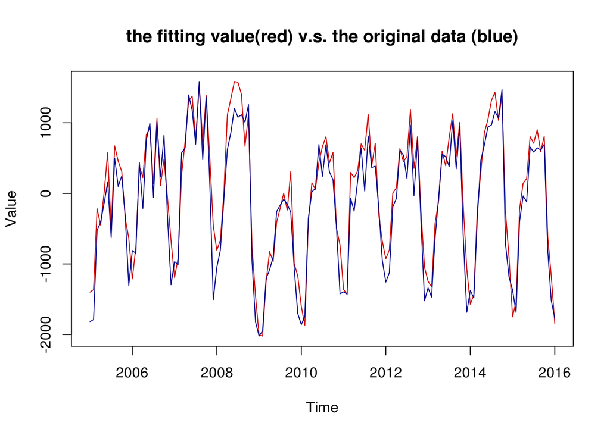

```r
library(forecast)
plot(ts(fitted(arima(u_hp,xreg=v_hp,order=c(4,0,0),seasonal = list(order = c(1,0,4), Period = 12), method = "ML")), start=2005, frequency = 12), ylab= "Value", col = "red3", main = "the fitting value(red) v.s. the original data (blue)")
par(new = T)
plot(u_hp,col="darkblue",type="l",axes=FALSE,xlab="",ylab="")
```

Roughly analyzing this plot, we can accept that this fitting value has consideriablely well result.

### 3.2 Analysis of temporal differences

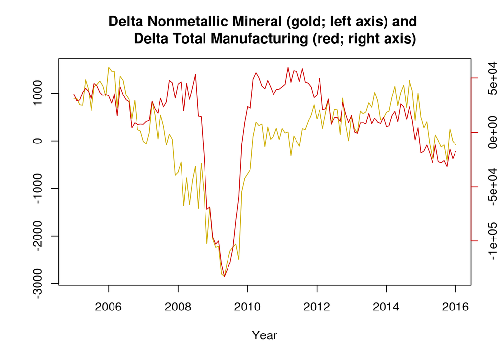

```r
delta_u <- u - Mine_data$NMUnAdj[Mine_data$Period %in% (t-1)]
delta_v <- v - Mine_data$TotalMUnAdj[Mine_data$Period %in% (t-1)]
plot(t,delta_u,type="l",xlab="Year",ylab="", col = "gold3",
     main = "Delta Nonmetallic Mineral (gold; left axis) and
     Delta Total Manufacturing (red; right axis)")
par(new=TRUE)
plot(t,delta_v,col="red3",type="l",axes=FALSE,xlab="",ylab="")
axis(side=4,col="red3")
```

We can see that the relationship between these two lines are weaker than the two lines detrended by HP-filter. The major difference are just before and after the great recession at 2008 to 2010. We could carefully conclude that those the change of Nonmetallic Mineral Products and Total Manufacturing Products are behavior relatively different under major fluctuation on U.S. general economic situation. Therefore, from this plot, we could anticipate that this method could not give us a better model than the model used HP-filter.

### 3.3 Model by A band pass filter

#### 3.3.1 Spectrum Analysis

Before we do the band pass filter, looking at spectrum density to search for significant periods.

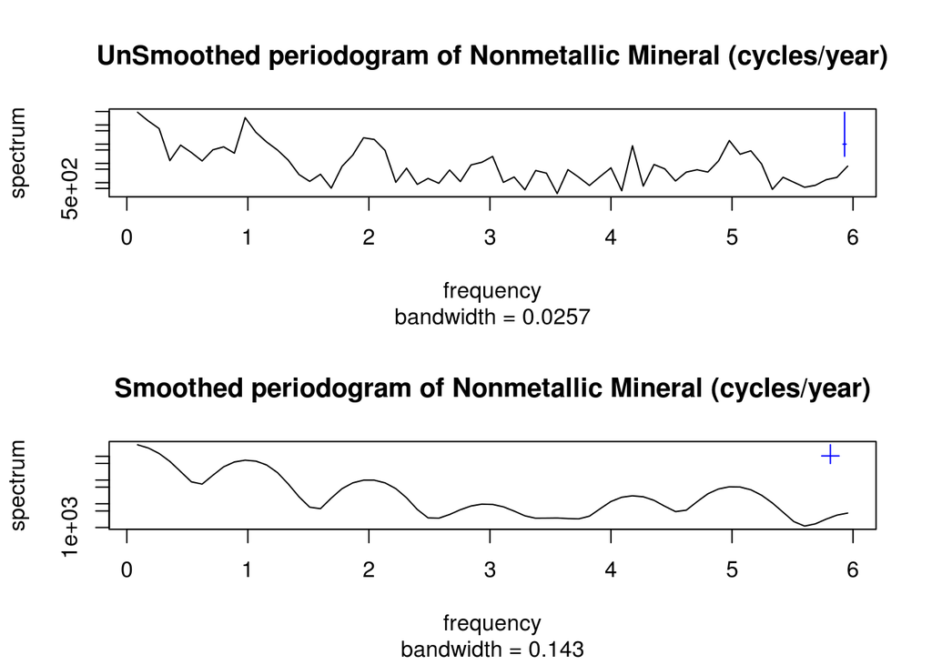

```r
par(mfrow = c(2,1))
spectrum(ts(u,frequency = 12), main="UnSmoothed periodogram of Nonmetallic Mineral (cycles/year)")
spectrum(ts(u,frequency = 12), span = c(3,5,3), main="Smoothed periodogram of Nonmetallic Mineral (cycles/year)")
```

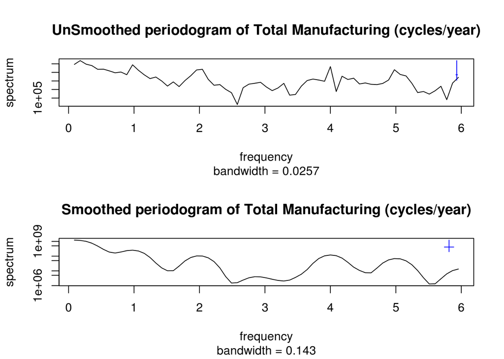

```r
par(mfrow = c(2,1))
spectrum(ts(v,frequency = 12), main="UnSmoothed periodogram of Total Manufacturing (cycles/year)")
spectrum(ts(v,frequency = 12), span = c(3,5,3), main="Smoothed periodogram of Total Manufacturing (cycles/year)")
```

We see both Time series are having many statistical significant periods. Because the unit for those graphs are cycles per year. We observe that there are 1, 2, 4, 5, and 6 cycles per year clearly. 3 cycles per year is uneasy to decide, therefore we don’t count it. These indicates that our data have yearly, half-yearly, quarterly and many cycles. Since we know that already, we could do the band pass filter.

#### 3.3.2 A band pass filter

For both time series, low frequency variation could be considered as trend and high frequency variation is considered as “noise”. Then we get the medium frequency variation is considered as business cycles with monthly data.

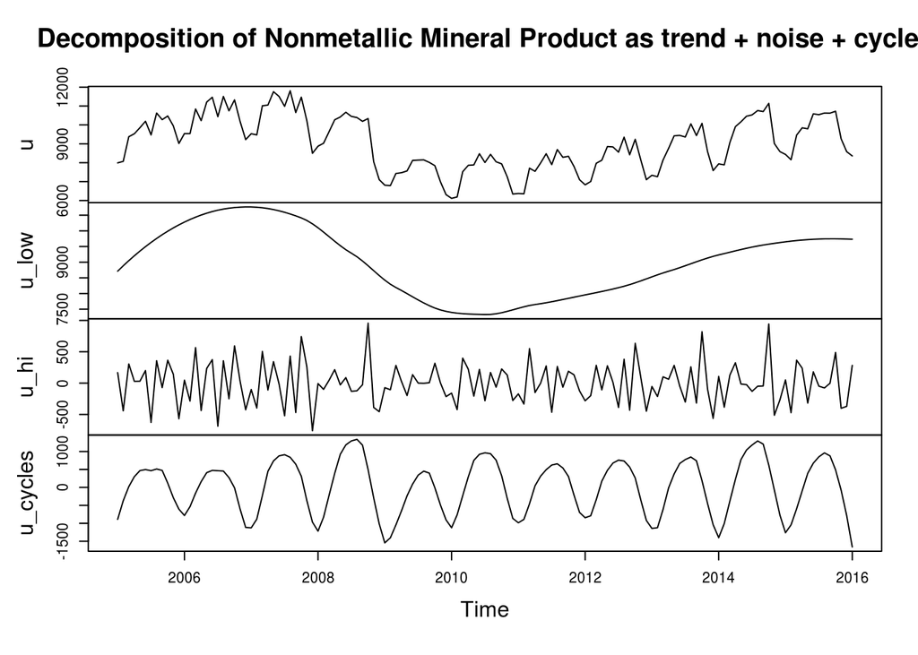

```r
u_low <- ts(loess(u~t,span=0.5)$fitted,start=2005,frequency=12)
u_hi <- ts(u - loess(u~t,span=0.08)$fitted,start=2005,frequency=12)
u_cycles <- u - u_hi - u_low
plot(ts.union(u, u_low,u_hi,u_cycles),
     main="Decomposition of Nonmetallic Mineral Product as trend + noise + cycles")
```

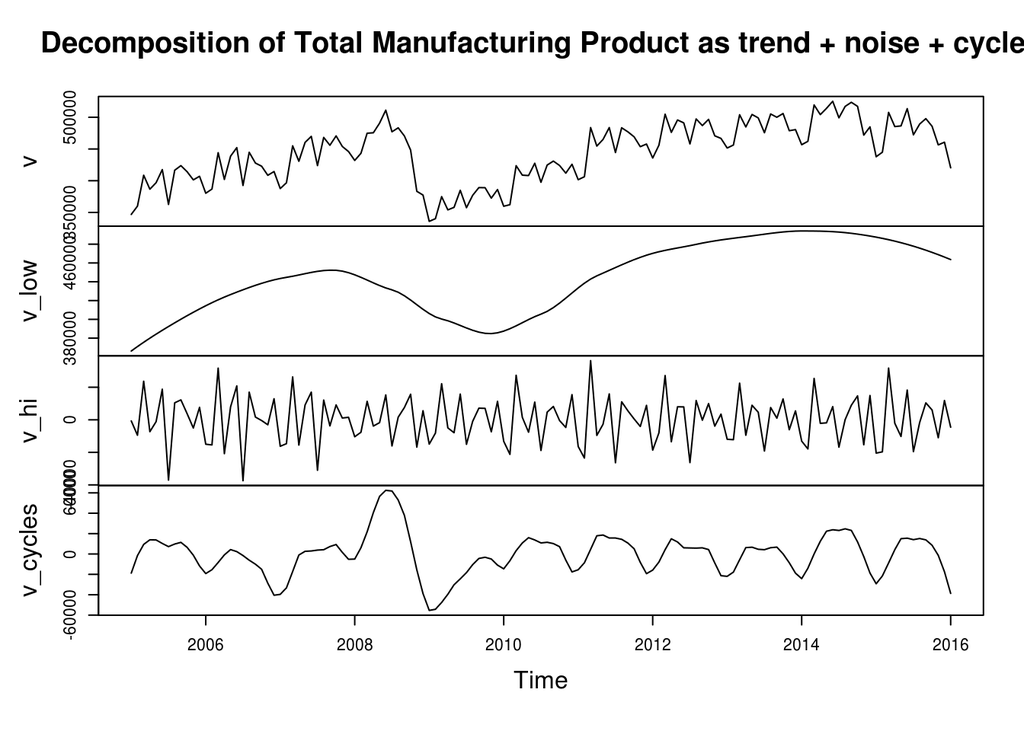

```r
v_low <- ts(loess(v~t,span=0.5)$fitted,start=2005,frequency=12)
v_hi <- ts(v - loess(v~t,span=0.08)$fitted,start=2005,frequency=12)
v_cycles <- v - v_hi - v_low
plot(ts.union(v, v_low,v_hi,v_cycles),
     main="Decomposition of Total Manufacturing Product as trend + noise + cycles")
```

Comparing two cycles part:

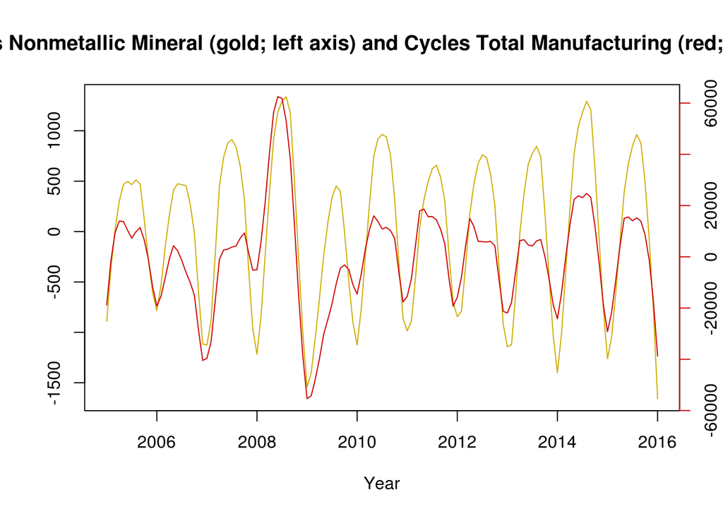

```r
plot(t,u_cycles,type="l",xlab="Year",ylab="", col = "gold3",
     main = "Cycles Nonmetallic Mineral (gold; left axis) and Cycles Total Manufacturing (red; right axis)")
par(new=TRUE)
plot(t,v_cycles,col="red3",type="l",axes=FALSE,xlab="",ylab="")
axis(side=4,col="red3")
```

```r
u_aic_table_3 <- aic_table(u_cycles,4,4,v_cycles)
require(knitr)
kable(u_aic_table_3,digits=2)
```

|  | MA0 | MA1 | MA2 | MA3 | MA4 |
| --- | --- | --- | --- | --- | --- |
| **AR0** | 2005.50 | 1839.14 | 1718.27 | 1655.02 | 1572.24 |
| **AR1** | 1765.99 | 1637.85 | 1601.78 | 1550.40 | 1526.46 |
| **AR2** | 1532.82 | 1527.18 | 1529.14 | 1502.82 | 1499.33 |
| **AR3** | 1525.87 | 1525.34 | 1526.46 | 1502.53 | 1506.82 |
| **AR4** | 1526.43 | 1525.45 | 1526.35 | 1500.52 | 1501.10 |

The table suggest we should take $p=3$ and $q=1$. Then we can fit SAR and SMA.

```r
aic_table_4 <- function(data,P,Q,xreg=NULL){
  table <- matrix(NA,(P+1),(Q+1))
  for(p in 0:P) {
    for(q in 0:Q) {
      table[p+1,q+1] <- arima(data,order=c(3,0,1),xreg=xreg, seasonal = list(order = c(p,0,q), Period = 12), method = "ML")$aic
    }
  }
  dimnames(table) <- list(paste("<b> SAR",0:P, "</b>", sep=""),paste("SMA",0:Q,sep=""))
  table
}
u_aic_table_4 <- aic_table_4(u_cycles,3,3,xreg=v_cycles)
require(knitr)
kable(u_aic_table_4,digits=2)
```

|  | SMA0 | SMA1 | SMA2 | SMA3 |
| --- | --- | --- | --- | --- |
| **SAR0** | 1525.34 | 1520.79 | 1516.85 | 1517.82 |
| **SAR1** | 1514.54 | 1504.88 | 1504.24 | 1505.36 |
| **SAR2** | 1513.07 | 1504.28 | 1506.19 | 1505.44 |
| **SAR3** | 1514.46 | 1506.03 | 1506.77 | 1506.10 |

This table shows we finally should fit a SARIMA$(3,0,1)\times(1,0,2)_{12}$ model.

#### 3.3.3 Supplementary analysis of SARIMA$(3,0,1)\times(1,0,2)_{12}$

```r
arima(u_hp,xreg=v_hp,order=c(3,0,1),seasonal = list(order = c(1,0,2), Period = 12), method = "ML")
```

```
##
## Call:
## arima(x = u_hp, order = c(3, 0, 1), seasonal = list(order = c(1, 0, 2), Period = 12),
##     xreg = v_hp, method = "ML")
##
## Coefficients:
##           ar1      ar2     ar3      ma1    sar1    sma1    sma2  intercept
##       -0.4095  -0.4048  0.5926  -0.1205  0.5930  0.9472  0.9378   -27.6098
## s.e.   0.1337   0.1339  0.1335   0.1595  0.1336  0.0769  0.0890   126.0358
##         v_hp
##       0.0275
## s.e.  0.0012
##
## sigma^2 estimated as 84144:  log likelihood = -946.94,  aic = 1913.88
```

This shows that almost all the coefficient are statistically significant by standard error calculated from Fisher information.

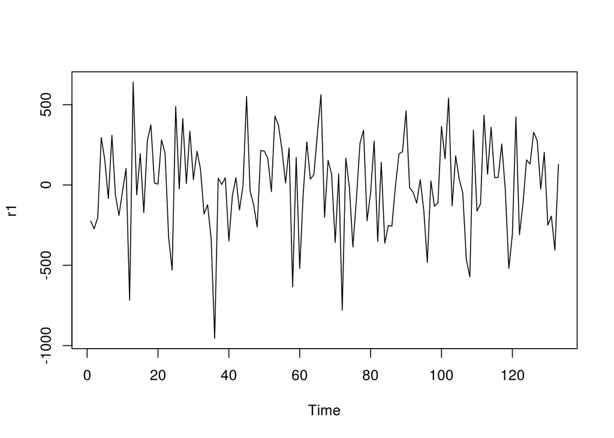

```r
r1 <- resid(arima(u_hp,xreg=v_hp,order=c(3,0,1),seasonal = list(order = c(1,0,2), Period = 12), method = "ML"))
plot(r1)
```

The residual plot still shows some mild periods, to confirm that, we do the acf plot next.

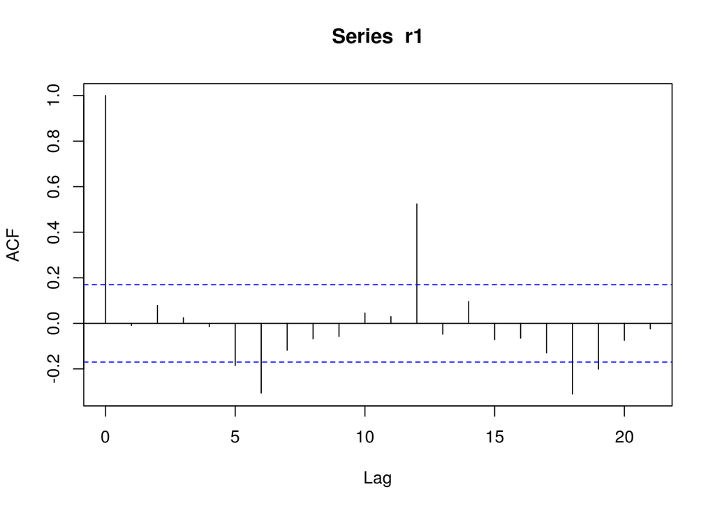

```r
acf(r1)
```

This Acf plot shows the residual are hardly Gaussian white noise. It is even have more lags out of dashed line then the previously model using HP-Filter. This means many seasonal information are left in the noise. We should not accpet this will be a result from a good model.

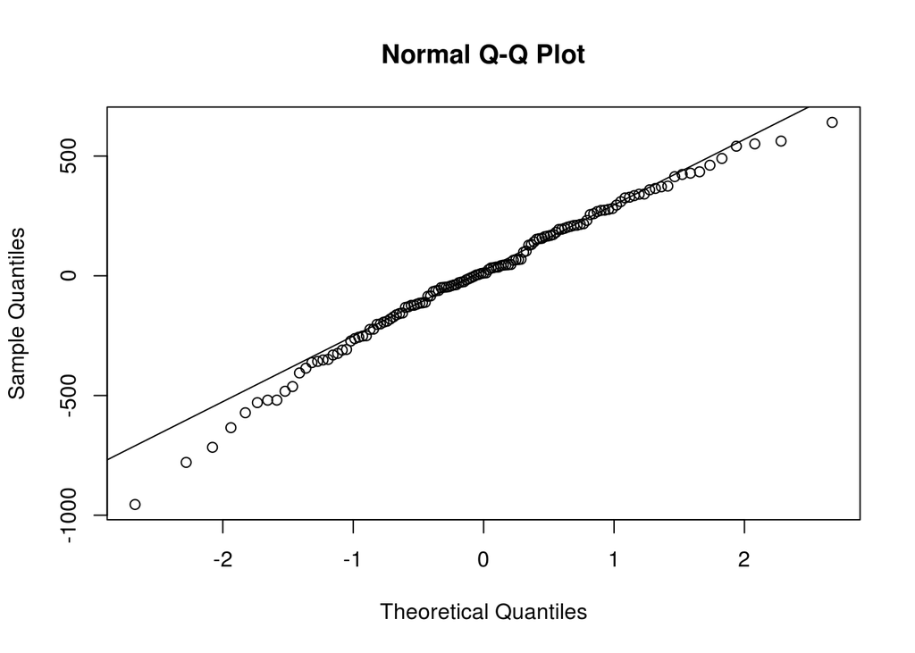

```r
qqnorm(r1)
qqline(r1)
```

Also the Q-Q plot shows that the residual are clearly skewed from normal distribution.

#### 3.3.4 Fitting Model SARIMA$(3,0,1)\times(1,0,2)_{12}$ V.S. Original data

Let’s plot the fitted value v.s. cycles of Nonmetallic Mineral Product.

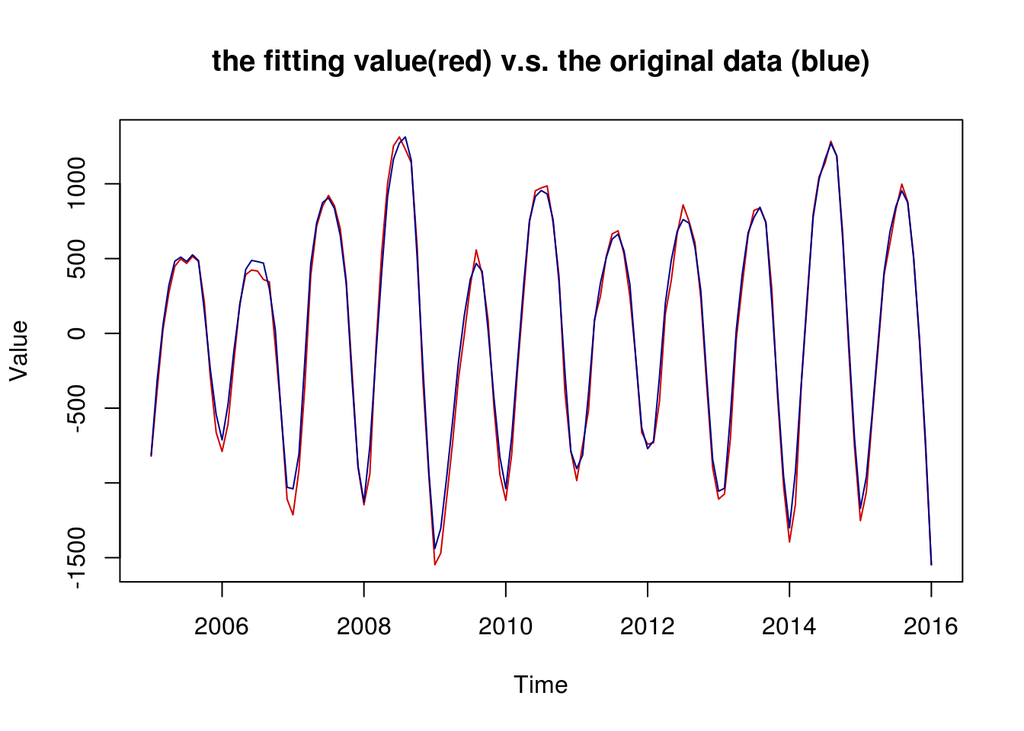

```r
library(forecast)
plot(ts(fitted(arima(u_cycles,xreg=v_cycles,order=c(3,0,1),seasonal = list(order = c(1,0,2), Period = 12), method = "ML")), start=2005, frequency = 12), ylab= "Value", col = "red3", main = "the fitting value(red) v.s. the original data (blue)")
par(new = T)
plot(u_cycles,col="darkblue",type="l",axes=FALSE,xlab="",ylab="")
```

We could see that the fitted value produced by model almost fit actual data perfectly. However, combining the result that this model has non-Gaussian white noise, we might accept this model by assuming residuals are not white noise from the beginning. If we think the true model residuals are white noise and our model left information in the residual. We should think that this fitted model might be bad on prediction.

## 5. Reference

Ogburn, W. F., and D. S. Thomas. 1922. The influence of the business cycle on certain social conditions. Journal of the American Statistical Association 18:324-340. http://www.census.gov/manufacturing/m3/definitions/index.html  
http://ionides.github.io/531w16/notes6/notes6.html  
http://ionides.github.io/531w16/notes8/notes8.html  
http://ionides.github.io/531w16/notes10/notes10.html